# Curran_Thomas_HW2

Thomas Curran

4/27/2017

#### I) Introduction:

The advent of data visualization libraries in recent years has given researchers an unprecedented avenue to communicate data. The new avenue of visualization also has drawback, those drawbacks are compounded by the blitz of media that the average user encounters on a daily bassis. Ranging from television to social media, the average consumer is constantly bombarded with visual stimuli, and the most prominent of which are video or some sort of animation component to media. Given these conditions, it is imperative to understand whether or not movement (i.e. animation) can enhance or detract from the “story” that a visualization attempts to tell.

#### II) Hypothesis:

The question underlying this study is: does animation help or hinder a visualization’s ability to convey a data’s “story” better or worse than a traditional static image?

The research was conducted with the notion that adding animation (i.e. movement) to a visualization allows for viewers to interpret the data’s “story” just as well if not better than if the visualization was static.

#### III) Visaulization Design:

To test the hypothesis, I considered several important factors. First, the data had to tell a story over time. Incorporating time as a method for conveying a data’s story is important in testing the hypothesis because motion can easily express time and directionality much in the way that traditional scatter plots do using lines of best fit or other methods. The visualizations used the built in data set in R called gapminder. the gapminder data set contains variables for country, continent (of the country), year measurement was taken, the country’s average life expectency, the country’s population in that year, and the gdp per capita.

The tested visualizations did not include any sort of lines of best fit of regression lines because it compromised the integrity and spirit of the survey questions in that a line would to easily give away the “story”, making it impossibly to distinguish the level of viewer understanding because it would not be able to distinguish whether they learned the story from the line in both graphs, or from th animation thereby defeating the point of the experiment. Furthermore, the data points plotted on both graphs are the same, but only a small subset of the data for countries available in the gapminder data set.

Other controls that were included in the creation of the visualizations were the colors of the data points, both graphs having the same set of data points and colors, as well as both graphs having had the legend removed. The legend was removed in an attempt to reduce bias from the person taking the survey.

The visualization used the R packages ggplot2, gganimate (from github), tidyverse and dataset (where gapminder data set is stored). The data used for the visualizations was a pre-existing data set sourced from R cran.

The first graph is the control, where it reflects the traditional, static visualization:

##### Image: ‘Static Graph’

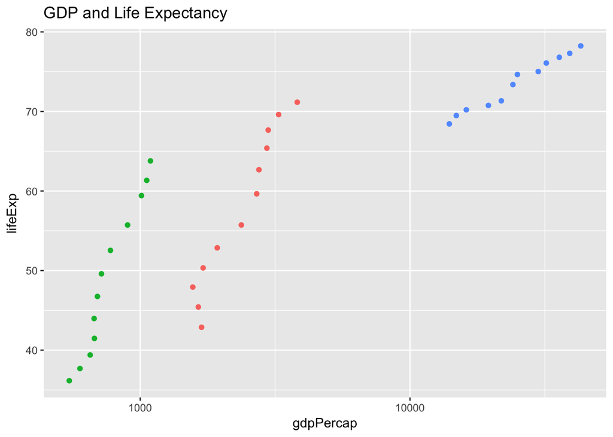

```r
data <- filter(gapminder,
               country == 'Nepal' |
                 country=='United States' |
                 country == 'Morocco'
)
p <- ggplot(data, aes(gdpPercap, lifeExp, color = country, frame = year)) +
  geom_point() +
  scale_x_log10() +
  theme(legend.position="none")+
  ggtitle("GDP and Life Expectancy")
p
```

The second graph mirrored the first graph, except this time instead showing every point at once, it showed each data point for every increase in the time interval.

#### Image: ‘Animated Graph’

```r
#note to view the animation in the HTML version I had to install ffmpeg via
#command line and homebrew with "brew install ffmpeg"
data <- filter(gapminder,
               country == 'Nepal' |
                 country=='United States' |
                 country == 'Morocco'
)
p <- ggplot(data, aes(gdpPercap, lifeExp, color = country, frame = year)) +
  geom_point() +
  scale_x_log10() +
  theme(legend.position="none")+
  ggtitle("GDP and Life Expectantcy")
gganimate(p)
```

[video not shown]

#### IV) Methodology

The questions were as follows:

1)If a line of best fit was drawn through each set of points on the graph, which two colors would have the most similar slope? 2)Which country has the highest life expectancy 3)Which two colors showed a similar change in GDP 4)Which statement best reflects the relationship between life expectancy and gdp based on the graph?

The survey randomized whether or not the respondent was shown the static image or the animated image, but the questions remained the same regardless of which visualization was shown. the aim of these questions was to measure the influence of motion on the respondent’s understanding of the graph

The survey was then deployed on Amazon’s Mechanical Turk for random respondents to take the survey. Qualtrics then collected the data for analysis.

#### V) Results:

| Time | means |
| --- | --- |
| Average Time | 102.33333 secs |
| Average time to complete animted | 126.95652 secs |
| Average time to complete static | 82.10714 secs |

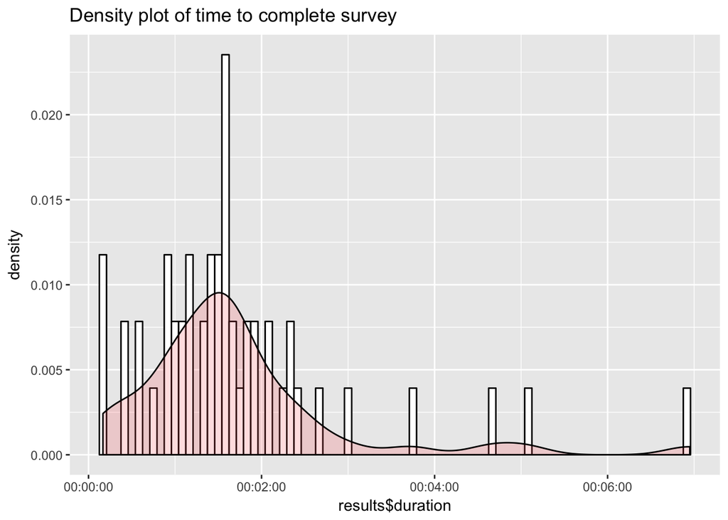

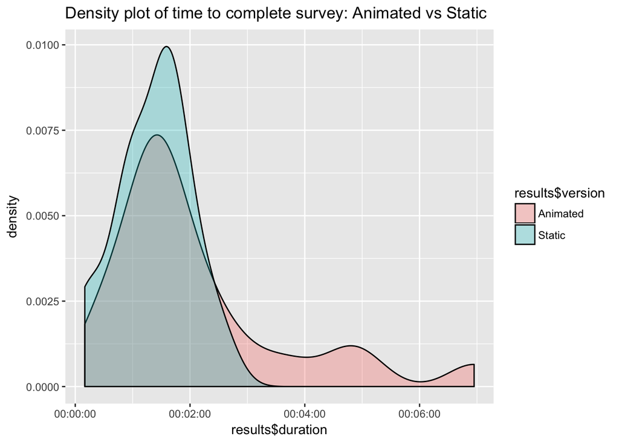

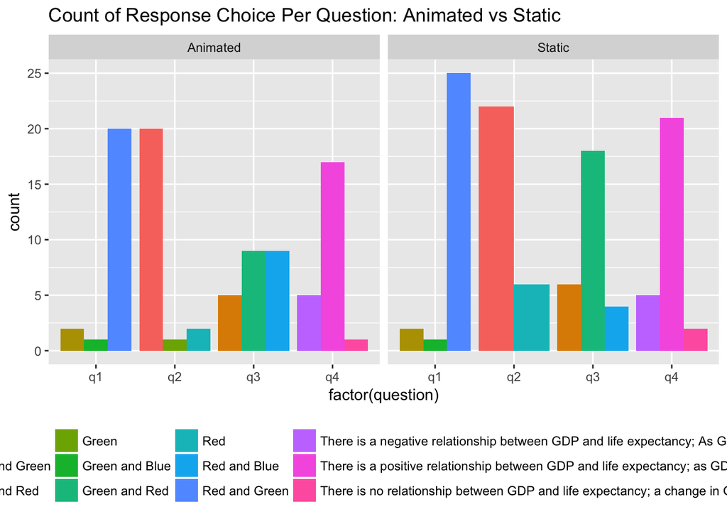

#### VI) Analysis

After exploring the differences in the responses, I analyzed the differences in time taken to complete the survey. As shown in table 1, on average the respondents that answered questions on the static image took approximately 82 second (1.5 minutes), where as respondents to the animated survey took approximately 2 minutes to complete the survey.